# Looking through NYC Jobs

In this notebook, we will look through the job postings available on the City of New York’s official jobs site. With this analysis, we would like to answer questions like, what type of jobs get posted, what’s the salary variation etc.

Required Packages

```r
library(readxl) #reading csv files
library(tidyverse) #metapackage for plotting and data manipulation
library(magrittr) #pipe operator
library(tm) #for text mining
library(SnowballC) #for stemming
library(wordcloud) #for plotting wordcloud
library(RColorBrewer) #for color pallette
library(ggmap) #for getting geocodes
library(leaflet) #for plotting map
library(mapview)
```

Custom Functions

```r
graph_save = function(title){
  ggsave(title, path = './output', device = 'jpeg')
}

text_operation = function(text_vector, words_to_remove){
  corpus = Corpus(VectorSource(text_vector))
  cleaned_data = corpus %>% tm_map(., stripWhitespace) %>% tm_map(., tolower) %>%
    tm_map(., removePunctuation) %>% tm_map(., removeNumbers) %>% tm_map(., removeWords, stopwords("en"))

  if(missing(words_to_remove)){
    return(cleaned_data)
  }else{
    cleaned_data = tm_map(cleaned_data, removeWords, words_to_remove)
    return(cleaned_data)
  }
}
```

Importing dataset

```r
nyc_jobs = read_csv('./input/nyc-jobs.csv')
glimpse(nyc_jobs)
```

```
## Observations: 3,116
## Variables: 28
## $ `Job ID`                        <dbl> 87990, 97899, 132292, 132292, ...
## $ Agency                          <chr> "DEPARTMENT OF BUSINESS SERV."...
## $ `Posting Type`                  <chr> "Internal", "Internal", "Exter...
## $ `# Of Positions`                <dbl> 1, 1, 52, 52, 50, 50, 1, 1, 1,...
## $ `Business Title`                <chr> "Account Manager", "EXECUTIVE ...
## $ `Civil Service Title`           <chr> "CONTRACT REVIEWER (OFFICE OF ...
## $ `Title Code No`                 <chr> "40563", "10009", "90698", "90...
## $ Level                           <chr> "1", "M3", "0", "0", "0", "0",...
## $ `Job Category`                  <chr> NA, NA, "Maintenance & Operati...
## $ `Full-Time/Part-Time indicator` <chr> NA, "F", "F", "F", "F", "F", "...
## $ `Salary Range From`             <dbl> 42405.00, 60740.00, 51907.68, ...
## $ `Salary Range To`               <dbl> 65485.00, 162014.00, 54580.32,...
## $ `Salary Frequency`              <chr> "Annual", "Annual", "Annual", ...
## $ `Work Location`                 <chr> "110 William St. N Y", "110 Wi...
## $ `Division/Work Unit`            <chr> "Strategy & Analytics", "Tech ...
## $ `Job Description`               <chr> "Division of Economic & Financ...
## $ `Minimum Qual Requirements`     <chr> "1.\tA baccalaureate degree fr...
## $ `Preferred Skills`              <chr> "â€¢\tExcellent interpersonal ...
## $ `Additional Information`        <chr> "Salary range for this positio...
## $ `To Apply`                      <chr> NA, "In addition to applying t...
## $ `Hours/Shift`                   <chr> NA, NA, NA, NA, NA, NA, NA, "3...
## $ `Work Location 1`               <chr> NA, NA, NA, NA, NA, NA, "42-09...
## $ `Recruitment Contact`           <lgl> NA, NA, NA, NA, NA, NA, NA, NA...
## $ `Residency Requirement`         <chr> "New York City residency is ge...
## $ `Posting Date`                  <dttm> 2011-06-24, 2012-01-26, 2013-...
## $ `Post Until`                    <dttm> NA, NA, NA, NA, NA, NA, NA, N...
## $ `Posting Updated`               <dttm> 2011-06-24, 2012-01-26, 2013-...
## $ `Process Date`                  <dttm> 2019-07-09, 2019-07-09, 2019-...
```

Looking at the dataset, we can answer the following question:

1. Which agency has posted the maximum number of jobs?
2. Which agency has posted highest salary and which agency has posted lowest salary?
3. What is the minimum qualification required for highest salary job and lowest salary job?
4. Where are the highest salary jobs located or concentrated?

With time, if any new question pops in mind, I will add to the list

Let’s start answering:

1. Which agency has posted the maximum number of jobs?

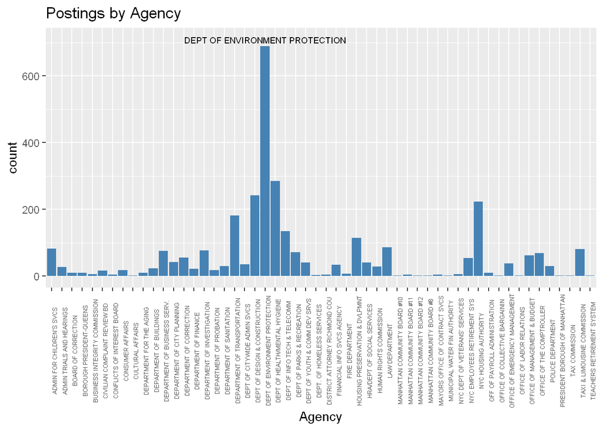

```r
data = nyc_jobs %>% group_by(Agency) %>% summarize(n()) %>% set_colnames(c("agency", "count"))

ggplot(nyc_jobs, aes(x = Agency)) +
  geom_bar(fill = 'steelblue') +
  theme(axis.text.x = element_text(angle = 90, size = 5)) +
  ggplot2::annotate('text',
           x = as.numeric(which.max(data$count)),
           y = as.numeric(data[which.max(data$count), 2]) + 20,
           label = as.character(data[which.max(data$count),1]),
           size = 2.5) +
  labs(title = 'Postings by Agency')
```

```r
graph_save('agency_postings.jpeg')

head(arrange(data, desc(count)))
```

```
## # A tibble: 6 x 2
##   agency                         count
##   <chr>                          <int>
## 1 DEPT OF ENVIRONMENT PROTECTION   689
## 2 DEPT OF HEALTH/MENTAL HYGIENE    285
## 3 DEPT OF DESIGN & CONSTRUCTION    242
## 4 NYC HOUSING AUTHORITY            223
## 5 DEPARTMENT OF TRANSPORTATION     182
## 6 DEPT OF INFO TECH & TELECOMM     134
```

```r
tail(arrange(data, desc(count)))
```

```
## # A tibble: 6 x 2
##   agency                         count
##   <chr>                          <int>
## 1 OFFICE OF COLLECTIVE BARGAININ     2
## 2 OFFICE OF LABOR RELATIONS          2
## 3 PRESIDENT BOROUGH OF MANHATTAN     2
## 4 TAX COMMISSION                     2
## 5 MANHATTAN COMMUNITY BOARD #12      1
## 6 TEACHERS RETIREMENT SYSTEM         1
```

1.1 Maximum number of posting are by Dept of Environment Protection.

1.2 Minimum number of posting are by Manhattan community board #12, Teachers Retirement System.

As each posting might have more than one job openings, to calculate the number of job openings, posting must be multiplied by number of job openings.

```r
total_jobs = sum(nyc_jobs$`# Of Positions`)
total_jobs
```

```
## [1] 9039
```

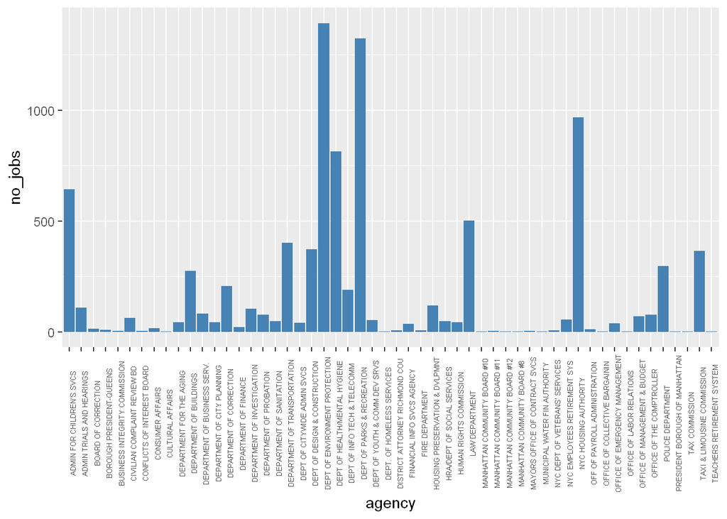

```r
#number of jobs with respect to agency
data = nyc_jobs %>% group_by(Agency) %>% summarize(sum(`# Of Positions`)) %>%
  set_colnames(c('agency', 'no_jobs')) %>% arrange(desc(no_jobs))

ggplot(data, aes(x = agency, y = no_jobs)) +
  geom_bar(fill = 'steelblue', stat = 'identity') +
  theme(axis.text.x = element_text(angle = 90, size = 5))
```

```r
graph_save('agency_jobs.jpeg')

head(data)
```

```
## # A tibble: 6 x 2
##   agency                         no_jobs
##   <chr>                            <dbl>
## 1 DEPT OF ENVIRONMENT PROTECTION    1393
## 2 DEPT OF PARKS & RECREATION        1323
## 3 NYC HOUSING AUTHORITY              967
## 4 DEPT OF HEALTH/MENTAL HYGIENE      814
## 5 ADMIN FOR CHILDREN'S SVCS          644
## 6 LAW DEPARTMENT                     503
```

```r
tail(data)
```

```
## # A tibble: 6 x 2
##   agency                         no_jobs
##   <chr>                            <dbl>
## 1 OFFICE OF COLLECTIVE BARGAININ       2
## 2 OFFICE OF LABOR RELATIONS            2
## 3 PRESIDENT BOROUGH OF MANHATTAN       2
## 4 TAX COMMISSION                       2
## 5 MANHATTAN COMMUNITY BOARD #12        1
## 6 TEACHERS RETIREMENT SYSTEM           1
```

1.3 Maximum number of jobs are from Dept of Environment Protection.

1.4 Minimum number of jobs are from Teachs Retirement System.

2. Which agency has posted highest salary and which agency has posted lowest salary?

The dataset contains the range of salary, as a conservative estimate of salary we can replace that range by the median of range.

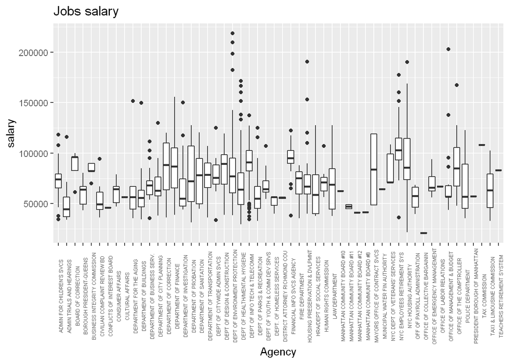

```r
#converting salary on hourly scale to annual scale and daily scale to yearly scale
#no of working days in US in a year: 261 source: https://hr.uiowa.edu/payroll/2019-fiscal-year-payroll-calendar
#no of working hours in US in a day: 8.4 hours source: Wikipedia

nyc_jobs = nyc_jobs %>% mutate(salary = if_else( `Salary Frequency` == "Annual", round((`Salary Range From` + `Salary Range To`)/2,2),
                                 if_else(`Salary Frequency` == "Daily", round((`Salary Range From` + `Salary Range To`)*261/2,2),
                                         round((`Salary Range From` + `Salary Range To`)*261*8.4/2,2))
                                 )
                               )

ggplot(nyc_jobs, aes(x = Agency, y = salary)) +
  geom_boxplot() +
  labs(title = "Jobs salary") +
  theme(axis.text.x = element_text(angle = 90, size = 5))
```

```r
graph_save('jobs_salary.jpeg')
```

2.1 Most of the jobs seem to lie between the bracked (50k, 100k).

2.2 Top five jobs with highest and lowest salary and posted by the agency:

```r
nyc_jobs %>% arrange(desc(salary)) %>% select(Agency, `Business Title`, salary) %>% unique() %>% head()
```

```
## # A tibble: 6 x 3
##   Agency                   `Business Title`                          salary
##   <chr>                    <chr>                                      <dbl>
## 1 DEPT OF ENVIRONMENT PRO~ Deputy Commissioner, Bureau of Customer ~ 2.19e5
## 2 DEPT OF ENVIRONMENT PRO~ Deputy Commissioner, Water and Sewer Ope~ 2.10e5
## 3 OFFICE OF MANAGEMENT & ~ BUDGET ANALYST (OMB)-MANAGERIA            2.03e5
## 4 DEPT OF ENVIRONMENT PRO~ Deputy Commissioner, Wastewater Treatment 1.99e5
## 5 HOUSING PRESERVATION & ~ Deputy Commissioner, Office of Policy an~ 1.91e5
## 6 HOUSING PRESERVATION & ~ Chief of Staff to the Commissioner        1.90e5
```

```r
nyc_jobs %>% arrange(desc(salary)) %>% select(Agency, `Business Title`, salary) %>% unique() %>% tail()
```

```
## # A tibble: 6 x 3
##   Agency                `Business Title`                             salary
##   <chr>                 <chr>                                         <dbl>
## 1 DEPARTMENT OF PROBAT~ Community Service Aide                       31372.
## 2 DEPT OF HEALTH/MENTA~ College Aide - Office Assistant, Bureau of ~ 30781.
## 3 DEPT OF HEALTH/MENTA~ Identification Associate/Clerical IB         30494.
## 4 DEPT OF HEALTH/MENTA~ Pest Control Aide, Bureau of Veterinary and~ 29561
## 5 NYC HOUSING AUTHORITY Caretaker I                                  21540.
## 6 OFFICE OF COLLECTIVE~ COLLEGE AIDE - CLERICAL                      20948.
```

3. What are the required qualification and skillset for the highest salary?

3.1 Minimum qualification required for high paying jobs, let’s say jobs whose annual salary is greater than 100k

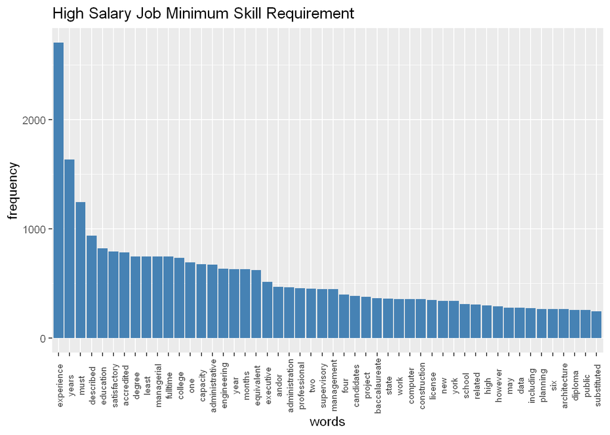

```r
high_salary_job = nyc_jobs %>% filter(salary >= 100000)

#preparing the word matrix
highsalary_reqskills = text_operation(high_salary_job$`Minimum Qual Requirements`)

word_matrix = as.matrix(TermDocumentMatrix(highsalary_reqskills))
summary = data.frame(sort(rowSums(word_matrix), decreasing = TRUE))
summary = data.frame(words = row.names(summary),frequency =  summary[,1], row.names = NULL)
summary$words = factor(summary$words, levels = summary$words[order(summary$frequency, decreasing = TRUE)])

#looking at the summary following words should to be removed
remove_words = c('must', 'andor', 'approved', 'may', 'related', 'areas', 'however', 'will', 'maximum', 'including', 'equivalent', 'york', 'substituted', 'large',
                  'six', 'two', 'least', 'valid', 'requirements', 'five', 'three', 'fouryear', 'months', 'years', 'year', 'described', 'satisfactory',
                 'one', 'four', 'new', 'â€œâ€')

highsalary_reqskills = text_operation(text_vector = high_salary_job$`Minimum Qual Requirements`, words_to_remove = remove_words)

#Plotting frequency plot
ggplot(summary[1:50, ], aes(words, frequency)) +
  geom_bar(fill = 'steelblue', stat = 'identity') +
  theme(axis.text.x = element_text(angle = 90, size = 7, vjust = 0.5)) +
  labs(title = 'High Salary Job Minimum Skill Requirement')
```

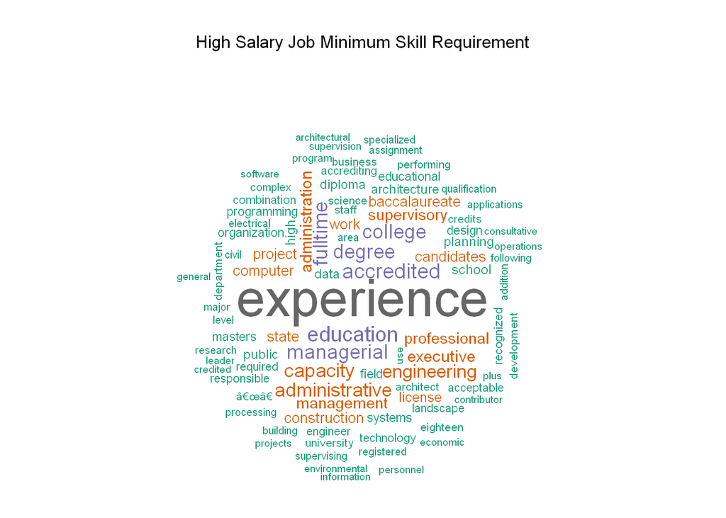

```r
graph_save('skill_req_highsalary_freqplot.jpeg')

#plotting wordcloud
layout(matrix(c(1, 2), nrow=2), heights=c(1, 5))
par(mar=rep(0, 4))
plot.new()
text(x=0.5, y=0.5, "High Salary Job Minimum Skill Requirement")
wordcloud(highsalary_reqskills, scale = c(3, 0.5), max.words = 100, min.freq = 100, random.order = FALSE, use.r.layout = TRUE,
          colors = brewer.pal(8, "Dark2"))
```

3.2 Minimum qualification required for low paying jobs, let’s say jobs whose annual salary is less than 50K

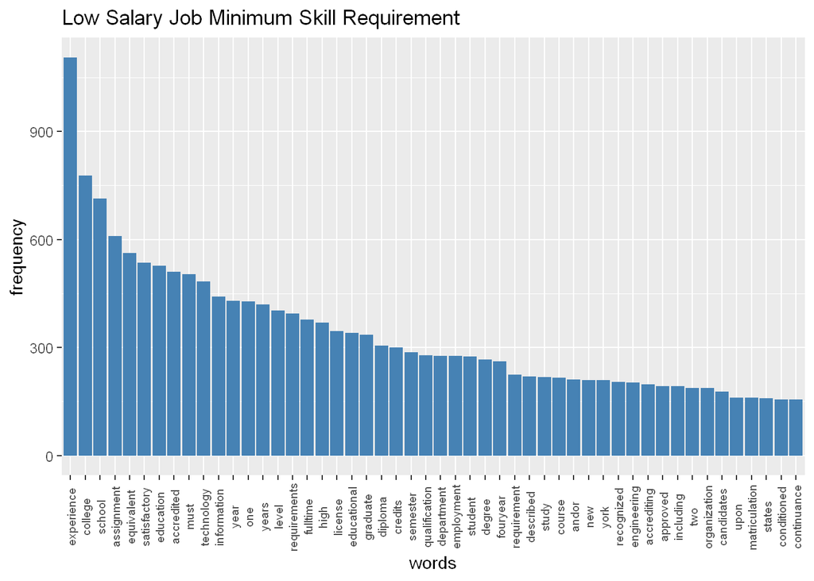

```r
low_salary_job = nyc_jobs %>% filter(salary <= 50000)

lowsalary_reqskills = text_operation(low_salary_job$`Minimum Qual Requirements`)

word_matrix = as.matrix(TermDocumentMatrix(lowsalary_reqskills))
summary = data.frame(sort(rowSums(word_matrix), decreasing = TRUE))
summary = data.frame(words = row.names(summary),frequency =  summary[,1], row.names = NULL)
summary$words = factor(summary$words, levels = summary$words[order(summary$frequency, decreasing = TRUE)])

#looking at the summary following words should to be removed
remove_words = c('must', 'andor', 'approved', 'may', 'related', 'areas', 'however', 'will', 'maximum', 'including', 'equivalent', 'york', 'substituted', 'large',
                  'six', 'two', 'least', 'valid', 'requirements', 'five', 'three', 'fouryear', 'months', 'years', 'year', 'described', 'satisfactory',
                 'one', 'four', 'new', 'â€œâ€')
lowsalary_reqskills = text_operation(text_vector = low_salary_job$`Minimum Qual Requirements`, words_to_remove = remove_words)

#plotting frequency plot
ggplot(summary[1:50, ], aes(words, frequency)) +
  geom_bar(fill = 'steelblue', stat = 'identity') +
  theme(axis.text.x = element_text(angle = 90, size = 7, vjust = 0.5)) +
  labs(title = 'Low Salary Job Minimum Skill Requirement')
```

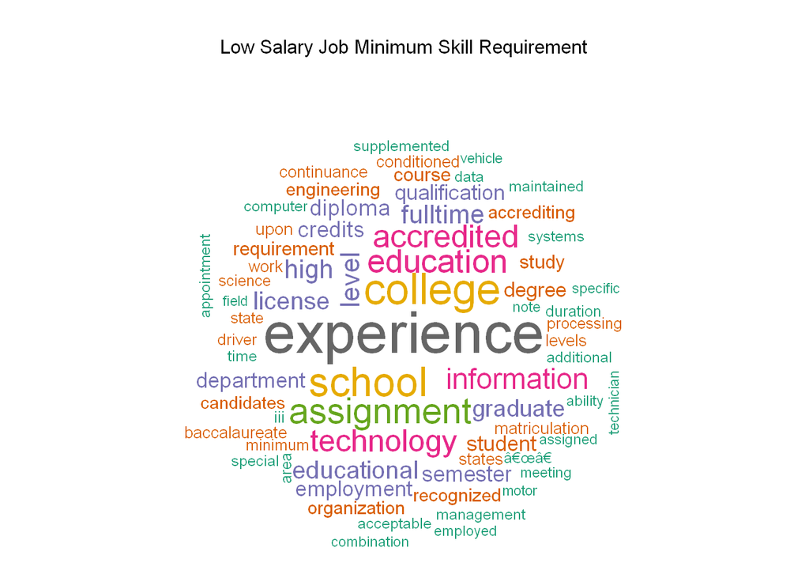

```r
graph_save('skill_req_lowsalary_freqplot.jpeg')

#plotting wordcloud
layout(matrix(c(1, 2), nrow=2), heights=c(1, 5))
par(mar=rep(0, 4))
plot.new()
text(x=0.5, y=0.5, "Low Salary Job Minimum Skill Requirement")
wordcloud(lowsalary_reqskills, scale = c(3, 0.5), max.words = 200, min.freq = 100, random.order = FALSE, use.r.layout = TRUE,
          colors = brewer.pal(8, "Dark2"))
```

4. Where are the high paying jobs located?

```r
high_salary_job = nyc_jobs %>% filter(salary >= 100000)

#geocode won't work without google api key

for(i in 1:nrow(high_salary_job)){
  result = geocode(high_salary_job$`Work Location`[i], source = 'google', output = 'latlona')
  if(!is.na(result[1])){
    high_salary_job$longitude[i] = as.numeric(result[1])
    high_salary_job$latitude[i] = as.numeric(result[2])
    high_salary_job$address[i] = as.character(result[3])
  }else{
    high_salary_job$latitude[i] = NA
    high_salary_job$longitude[i] = NA
    high_salary_job$address[i] = NA
  }
}

#writing to csv file, to prevent hitting google apis for coordinates, rather use this csv file
write_csv(high_salary_job, './output/high_salary_geocodes.csv')
```

```r
low_salary_job = nyc_jobs %>% filter(salary <=  50000)

#geocode won't work without google api key

for(i in 1:nrow(low_salary_job)){
  result = geocode(low_salary_job$`Work Location`[i], source = 'google', output = 'latlona')
  if(!is.na(result[1])){
    low_salary_job$longitude[i] = as.numeric(result[1])
    low_salary_job$latitude[i] = as.numeric(result[2])
    low_salary_job$address[i] = as.character(result[3])
  }else{
    low_salary_job$latitude[i] = NA
    low_salary_job$longitude[i] = NA
    low_salary_job$address[i] = NA
  }
}

#writing to csv file, to prevent hitting google apis for coordinates, rather use this csv file
write_csv(low_salary_job, './output/low_salary_geocodes.csv')
```

```r
high_salary_geocodes = read_csv('./output/high_salary_geocodes.csv')
low_salary_geocodes = read_csv('./output/low_salary_geocodes.csv')

#removing values for which there were no coordinates
high_salary_geocodes = high_salary_geocodes[-which(is.na(high_salary_geocodes$latitude)), ]
low_salary_geocodes = low_salary_geocodes[-which(is.na(low_salary_geocodes$latitude)), ]

#add custom color column
high_salary_geocodes$color = rep('Blue', nrow(high_salary_geocodes))
low_salary_geocodes$color = rep('Red', nrow(low_salary_geocodes))

salary_geocodes = rbind(high_salary_geocodes, low_salary_geocodes)

map = salary_geocodes %>% select('latitude', 'longitude', 'address', 'color') %>% leaflet(data = .) %>% addProviderTiles(providers$Esri) %>%
  setView(lat = 40.7128, lng = -74.0060, zoom = 11) %>%
  addTiles() %>% addCircleMarkers(lng = ~longitude, lat = ~latitude, radius = 3, color = ~color)

mapshot(map, file = paste0(getwd(), '/output/map.jpeg'), remove_controls = c('homeButton', 'layersControl'))

map
```

[interactive chart not shown]

4.1 High paying jobs are not as distributed as low paying jobs over New York.